# p8105_hw6_rk3445

Rosie Kwon

# Problem 1

```r
#Create a city_state variable, and a binary variable indicating whether the homicide is solved. Omit cities Dallas, TX; Phoenix, AZ; and Kansas City, MO – these don’t report victim race. Also omit Tulsa, AL – this is a data entry mistake. For this problem, limit your analysis those for whom victim_race is white or black. Be sure that victim_age is numeric.
homicides =
  read_csv("data/homicide-data.csv", na = c("NA", "Unknown", "")) |>
  janitor::clean_names() |>
  mutate(
    city_state = paste(city , state, sep = ", "),
    solve_status = case_match(
      disposition,
      "Closed without arrest" ~ 0,
      "Open/No arrest" ~ 0,
      "Closed by arrest" ~ 1
    ),
    victim_age = as.numeric(victim_age)
  ) |>
  filter(
    !(city_state %in% c("Dallas, TX", "Phoenix, AZ",
                         "Kansas City, MO", "Tulsa, AL")),
    victim_race %in% c("White", "Black")
  )
```

The dataset from Washington Post homicide data contains information about murders in U.S. cities, including:

- `uid`: unique identifier for each case
- `victim_last`, `victim_first`: victim’s name
- `victim_age`, `victim_sex`, `victim_race`: demographics of victims
- `city`, `state`: location
- `disposition`: whether the case was solved or not

Dataset includes a total of 39693 observations and 14 variables.

```r
#For the city of Baltimore, MD, use the glm function to fit a logistic regression with resolved vs unresolved as the outcome and victim age, sex and race as predictors. Save the output of glm as an R object;

homicides_md =
  homicides |>
  filter(
    city_state == "Baltimore, MD"
  )

fit_md =
  homicides_md |>
  glm(
    solve_status ~ victim_age + victim_sex + victim_race,
    family = binomial(),
    data = _)
```

```r
#apply the broom::tidy to this object; and obtain the estimate and confidence interval of the adjusted odds ratio for solving homicides comparing male victims to female victims keeping all other variables fixed.
result =
  broom::tidy(fit_md, conf.int = TRUE, exponentiate = TRUE)


result |>
  knitr::kable()
```

| term | estimate | std.error | statistic | p.value | conf.low | conf.high |
| --- | --- | --- | --- | --- | --- | --- |
| (Intercept) | 1.3633992 | 0.1712948 | 1.809635 | 0.0703525 | 0.9757573 | 1.9107826 |
| victim_age | 0.9932953 | 0.0033235 | -2.024124 | 0.0429574 | 0.9868059 | 0.9997539 |
| victim_sexMale | 0.4255117 | 0.1381762 | -6.183864 | 0.0000000 | 0.3241908 | 0.5575508 |
| victim_raceWhite | 2.3204389 | 0.1747162 | 4.817851 | 0.0000015 | 1.6496269 | 3.2759334 |

Since the results of a logistic regression model are given in log-odds, I took the exponential to convert the results to odd ratios (OR).

```r
result |>
  filter(term == "victim_sexMale") |>
  select(term, estimate, conf.low, conf.high) |>
  knitr::kable()
```

| term | estimate | conf.low | conf.high |
| --- | --- | --- | --- |
| victim_sexMale | 0.4255117 | 0.3241908 | 0.5575508 |

Male victims have a 0.42 times higher odds of having their homicide solved compared to female victims with holding other variables. The 95% confidence interval lies between 0.32 and 0.557.

```r
#Now run glm for each of the cities in your dataset
fit_cities = function(df){
  glm(
    solve_status ~ victim_age + victim_sex + victim_race,
    family = binomial(link = "logit"),
    data = df)
}

#Extract the adjusted odds ratio (and CI) for solving homicides comparing male victims to female victims. Do this within a “tidy” pipeline, making use of purrr::map, list columns, and unnest as necessary to create a dataframe with estimated ORs and CIs for each city.

nested_results =
  homicides |>
  nest(data = -city_state) |>
  mutate(
    fits = purrr::map(data, fit_cities),
    results = purrr::map(fits, ~broom::tidy(.x, conf.int = TRUE, exponentiate = TRUE))

  ) |>
  select(city_state, results) |>
  unnest(results) |>
  filter(term == "victim_sexMale") |>
  select(city_state, estimate, conf.low, conf.high)


knitr::kable(nested_results)
```

| city_state | estimate | conf.low | conf.high |
| --- | --- | --- | --- |
| Albuquerque, NM | 1.7674995 | 0.8247082 | 3.7618597 |
| Atlanta, GA | 1.0000771 | 0.6803477 | 1.4582575 |
| Baltimore, MD | 0.4255117 | 0.3241908 | 0.5575508 |
| Baton Rouge, LA | 0.3814393 | 0.2043481 | 0.6836343 |
| Birmingham, AL | 0.8700153 | 0.5713814 | 1.3138409 |
| Boston, MA | 0.6673219 | 0.3508461 | 1.2600381 |
| Buffalo, NY | 0.5205704 | 0.2884416 | 0.9358300 |
| Charlotte, NC | 0.8838976 | 0.5507440 | 1.3905954 |
| Chicago, IL | 0.4100982 | 0.3361233 | 0.5008546 |
| Cincinnati, OH | 0.3998277 | 0.2313767 | 0.6670456 |
| Columbus, OH | 0.5324845 | 0.3770457 | 0.7479124 |
| Denver, CO | 0.4790620 | 0.2327380 | 0.9624974 |
| Detroit, MI | 0.5823472 | 0.4619454 | 0.7335458 |
| Durham, NC | 0.8123514 | 0.3824420 | 1.6580169 |
| Fort Worth, TX | 0.6689803 | 0.3935128 | 1.1211603 |
| Fresno, CA | 1.3351647 | 0.5672553 | 3.0475080 |
| Houston, TX | 0.7110264 | 0.5569844 | 0.9057376 |
| Indianapolis, IN | 0.9187284 | 0.6784616 | 1.2413059 |
| Jacksonville, FL | 0.7198144 | 0.5359236 | 0.9650986 |
| Las Vegas, NV | 0.8373078 | 0.6058830 | 1.1510854 |
| Long Beach, CA | 0.4102163 | 0.1427304 | 1.0241775 |
| Los Angeles, CA | 0.6618816 | 0.4565014 | 0.9541036 |
| Louisville, KY | 0.4905546 | 0.3014879 | 0.7836391 |
| Memphis, TN | 0.7232194 | 0.5261210 | 0.9835973 |
| Miami, FL | 0.5152379 | 0.3040214 | 0.8734480 |
| Milwaukee, wI | 0.7271327 | 0.4951325 | 1.0542297 |
| Minneapolis, MN | 0.9469587 | 0.4759016 | 1.8809745 |
| Nashville, TN | 1.0342379 | 0.6807452 | 1.5559966 |
| New Orleans, LA | 0.5849373 | 0.4218807 | 0.8121787 |
| New York, NY | 0.2623978 | 0.1327512 | 0.4850117 |
| Oakland, CA | 0.5630819 | 0.3637421 | 0.8671086 |
| Oklahoma City, OK | 0.9740747 | 0.6228507 | 1.5199721 |
| Omaha, NE | 0.3824861 | 0.1988357 | 0.7109316 |
| Philadelphia, PA | 0.4962756 | 0.3760120 | 0.6498797 |
| Pittsburgh, PA | 0.4307528 | 0.2626022 | 0.6955516 |
| Richmond, VA | 1.0060520 | 0.4834671 | 1.9936248 |
| San Antonio, TX | 0.7046200 | 0.3928179 | 1.2382509 |
| Sacramento, CA | 0.6688418 | 0.3262733 | 1.3143887 |
| Savannah, GA | 0.8669817 | 0.4185827 | 1.7802453 |
| San Bernardino, CA | 0.5003444 | 0.1655367 | 1.4623977 |
| San Diego, CA | 0.4130248 | 0.1913527 | 0.8301847 |
| San Francisco, CA | 0.6075362 | 0.3116925 | 1.1551470 |
| St. Louis, MO | 0.7031665 | 0.5298505 | 0.9319005 |
| Stockton, CA | 1.3517273 | 0.6256427 | 2.9941299 |
| Tampa, FL | 0.8077029 | 0.3395253 | 1.8598834 |
| Tulsa, OK | 0.9757694 | 0.6090664 | 1.5439356 |
| Washington, DC | 0.6910490 | 0.4659731 | 1.0135014 |

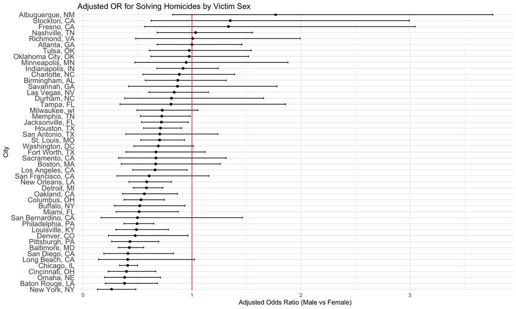

```r
#Create a plot that shows the estimated ORs and CIs for each city. Organize cities according to estimated OR, and comment on the plot.

nested_results |>
  mutate(city_state = fct_reorder(city_state, estimate)) |>
  ggplot(aes(x = city_state, y = estimate)) +
  geom_point() +
  geom_errorbar(aes(ymin = conf.low, ymax = conf.high), width = 0.3) +
  geom_hline(yintercept = 1, color = "red", linewidth = 0.4) +
  coord_flip() +
  scale_x_discrete(expand = expansion(add = 0.1)) +
  labs(
    x = "City",
    y = "Adjusted Odds Ratio (Male vs Female)",
    title = "Adjusted OR for Solving Homicides by Victim Sex"
  ) +
  theme_minimal() +
  theme(
    axis.text.y = element_text(size = 12, margin = margin(r = 10))
  )
```

I added OR = 1 as a reference line to interpret which victim of sex is more likely to be solved.

Cities including Albuquerque, Stockton, Fresno, and Nashville show ORs above 1, indicating that male-victim homicides are more likely to be solved. Those cities show the ORs with wide confidence intervals, suggesting strong differences but also high uncertainty.

When the 95% confidence interval includes 1, the difference is not statistically significant, meaning we cannot conclude that victim sex affects clearance rates in those cities. 95% confidence interval for the some of cities including 1 did not show statistically significant evidence that cases involving male victims are more likely to be solved than female victims.

Importantly, some cities such as Memphis, Jacksonville, Houston, New Orleans, Detroit, Oakland and New York have ORs below 1 and have statistical evidence that case with female victims are more likely to be solved than male victims.

# Problem 2

```r
#Load library and central Park weather data
library(p8105.datasets)
library(modelr)
data("weather_df")
```

A simple linear regression with tmax as the response with tmin and prcp as the predictors, and are interested in the distribution of two quantities estimated from these data: Use 5000 bootstrap samples and, for each bootstrap sample, produce estimates of these two quantities : $\hat{r}^2$, $\hat{\beta}_1 / \hat{\beta}_2$

```r
bootstrap_results =
  weather_df |>
  bootstrap(n = 5000) |>
  mutate(
    model = map(strap, \(df) lm(tmax ~ tmin + prcp, data = df)),
    r_sq = map_dbl(model, \(m) broom::glance(m)$r.squared),
    beta_ratio = map_dbl(model, \(m) {
      tbl = broom::tidy(m)
      b1 = tbl$estimate[tbl$term == "tmin"]
      b2 = tbl$estimate[tbl$term == "prcp"]
      b1 / b2
    })
  ) |>
  select(r_sq, beta_ratio)
```

Plot the distribution of your estimates, and describe these in words. Using the 5000 bootstrap estimates, identify the 2.5% and 97.5% quantiles to provide a 95% confidence interval for $\hat{r}^2$, $\hat{\beta}_1 / \hat{\beta}_2$

1. $\hat{r}^2$ estimate distribution

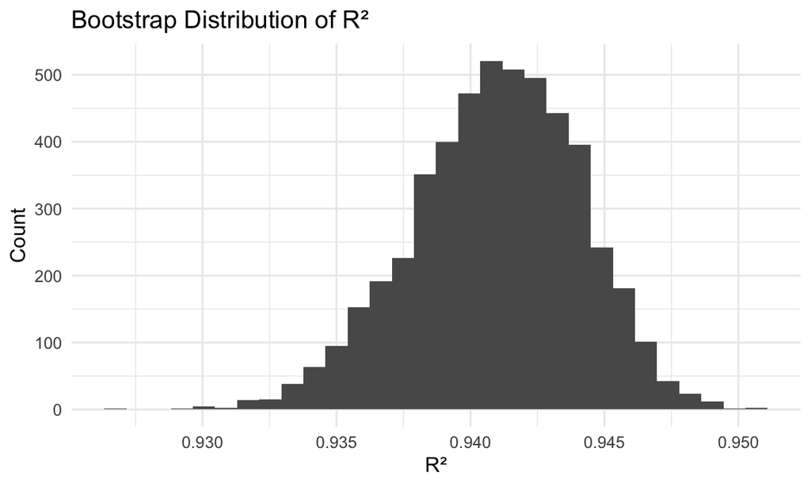

```r
bootstrap_results |>
  ggplot(aes(x = r_sq))+
  geom_histogram() +
  labs(
    title = "Bootstrap Distribution of R²",
    x = "R²",
    y = "Count"
  ) +
  theme_minimal()
```

Using 5000 times of bootstrap, the distribution of the r_squared value is approximatlly normal, centered around its mean of 0.9409563. Since r_squared is greater than 0.93, the power of the model is highly stable across resampled datasets.

```r
bootstrap_results |>
  summarize(
    ci_lower = quantile(r_sq, 0.025),
    ci_upper = quantile(r_sq, 0.975)
  ) |>
  knitr::kable()
```

| ci_lower | ci_upper |
| --- | --- |
| 0.9343767 | 0.9466277 |

The 95% bootstrap confidence interval of $\hat{r}^2$ is between 0.934 and 0.946.

2. $\hat{\beta}_1 / \hat{\beta}_2$ estimate distribution

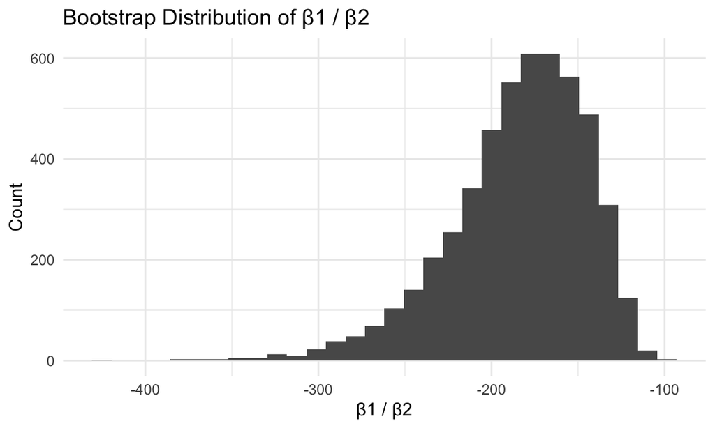

```r
bootstrap_results |>
  ggplot(aes(x = beta_ratio)) +
  geom_histogram() +
  labs(
    title = "Bootstrap Distribution of β1 / β2",
    x = "β1 / β2",
    y = "Count"
  ) +
  theme_minimal()
```

The ratio represents the change in `tmin` relative to `prcp` with the same change in `tmax`. The distribution of the ratio β1/β2 where β1 is estimate for `tmin` and β2 is estimate for `prcp`. It is left-skewed and wider and more variable because the precipitation coefficient is close to zero, making the ratio unstable and potentially very large in magnitude.

```r
bootstrap_results |>
  summarize(
    ci_lower = quantile(beta_ratio, 0.025),
    ci_upper = quantile(beta_ratio, 0.975)
  ) |>
  knitr::kable()
```

| ci_lower | ci_upper |
| --- | --- |
| -279.7489 | -125.6859 |

# Problem 3

Load and clean the data for regression analysis (i.e. use appropriate variable names, convert numeric to factor where appropriate, check for the presence of missing data, etc.).

```r
birthweight =
  read_csv("data/birthweight.csv") |>
  janitor::clean_names() |>
  mutate(
    babysex = factor(babysex,
                     levels = c(1, 2), labels = c("Male", "Female")),
    frace   = factor(frace,
                     levels = c(1,2,3,4,8,9),
                     labels = c("White", "Black", "Asian", "Puerto Rican",
                                "Other", "Unknown")),
    mrace   = factor(mrace,
                     levels = c(1,2,3,4,8),
                     labels = c("White", "Black", "Asian", "Puerto Rican", "Other")),
    malform = factor(malform, levels = c(0,1), labels = c("No", "Yes"))
  )
birthweight |> skimr::skim()
```

Data summary

| Name | birthweight |
| --- | --- |
| Number of rows | 4342 |
| Number of columns | 20 |
| _______________________ |  |
| Column type frequency: |  |
| factor | 4 |
| numeric | 16 |
| ________________________ |  |
| Group variables | None |

**Variable type: factor**

| skim_variable | n_missing | complete_rate | ordered | n_unique | top_counts |
| --- | --- | --- | --- | --- | --- |
| babysex | 0 | 1 | FALSE | 2 | Mal: 2230, Fem: 2112 |
| frace | 0 | 1 | FALSE | 5 | Whi: 2123, Bla: 1911, Pue: 248, Asi: 46 |
| malform | 0 | 1 | FALSE | 2 | No: 4327, Yes: 15 |
| mrace | 0 | 1 | FALSE | 4 | Whi: 2147, Bla: 1909, Pue: 243, Asi: 43 |

**Variable type: numeric**

| skim_variable | n_missing | complete_rate | mean | sd | p0 | p25 | p50 | p75 | p100 | hist |
| --- | --- | --- | --- | --- | --- | --- | --- | --- | --- | --- |
| bhead | 0 | 1 | 33.65 | 1.62 | 21.00 | 33.00 | 34.00 | 35.00 | 41.0 | ▁▁▆▇▁ |
| blength | 0 | 1 | 49.75 | 2.72 | 20.00 | 48.00 | 50.00 | 51.00 | 63.0 | ▁▁▁▇▁ |
| bwt | 0 | 1 | 3114.40 | 512.15 | 595.00 | 2807.00 | 3132.50 | 3459.00 | 4791.0 | ▁▁▇▇▁ |
| delwt | 0 | 1 | 145.57 | 22.21 | 86.00 | 131.00 | 143.00 | 157.00 | 334.0 | ▅▇▁▁▁ |
| fincome | 0 | 1 | 44.11 | 25.98 | 0.00 | 25.00 | 35.00 | 65.00 | 96.0 | ▃▇▅▂▃ |
| gaweeks | 0 | 1 | 39.43 | 3.15 | 17.70 | 38.30 | 39.90 | 41.10 | 51.3 | ▁▁▂▇▁ |
| menarche | 0 | 1 | 12.51 | 1.48 | 0.00 | 12.00 | 12.00 | 13.00 | 19.0 | ▁▁▂▇▁ |
| mheight | 0 | 1 | 63.49 | 2.66 | 48.00 | 62.00 | 63.00 | 65.00 | 77.0 | ▁▁▇▂▁ |
| momage | 0 | 1 | 20.30 | 3.88 | 12.00 | 18.00 | 20.00 | 22.00 | 44.0 | ▅▇▂▁▁ |
| parity | 0 | 1 | 0.00 | 0.10 | 0.00 | 0.00 | 0.00 | 0.00 | 6.0 | ▇▁▁▁▁ |
| pnumlbw | 0 | 1 | 0.00 | 0.00 | 0.00 | 0.00 | 0.00 | 0.00 | 0.0 | ▁▁▇▁▁ |
| pnumsga | 0 | 1 | 0.00 | 0.00 | 0.00 | 0.00 | 0.00 | 0.00 | 0.0 | ▁▁▇▁▁ |
| ppbmi | 0 | 1 | 21.57 | 3.18 | 13.07 | 19.53 | 21.03 | 22.91 | 46.1 | ▃▇▁▁▁ |
| ppwt | 0 | 1 | 123.49 | 20.16 | 70.00 | 110.00 | 120.00 | 134.00 | 287.0 | ▅▇▁▁▁ |
| smoken | 0 | 1 | 4.15 | 7.41 | 0.00 | 0.00 | 0.00 | 5.00 | 60.0 | ▇▁▁▁▁ |
| wtgain | 0 | 1 | 22.08 | 10.94 | -46.00 | 15.00 | 22.00 | 28.00 | 89.0 | ▁▁▇▁▁ |

The birthweight dataset has 4342 infants data with 20 measurements. It is cleaned by standardizing variable names, converting appropriate numeric variables (infant sex, malformations, father’s race, mother’s race) into factors. I verified that the dataset doesn’t contain any missing values.

```r
#Propose a regression model for birthweight. This model may be based on a hypothesized structure for the factors that underly birthweight, on a data-driven model-building process, or a combination of the two.

linear_prop = lm(
    bwt ~ bhead + blength + gaweeks + ppbmi + smoken + wtgain + babysex,
    data = birthweight)
```

Based on scientific knowledge, a child’s birthweight is influenced by factors related to by the size of the baby at birth, the gestational period, and the mother’s health and lifestyle during pregnancy.

- Head circumference (bhead) & body length (blength): Direct measurements of infant size at birth, expected to be highly correlated with weight.
- Gestational period (gaweeks): Longer gestation makes more fetal development, resulting in higher birth weight.
- Maternal pre-pregnancy BMI (ppbmi): Mother’s BMI reflects maternal nutritional status and overall health status.
- Maternal weight gain (wtgain): linked to fetal growth, meaning that sufficient weight gain is linked to higher birth weight.
- Smoking during pregnancy (smoken): It is well-known risk factor for reduced fetal growth due to decreased oxygen supply.
- Baby’s sex (babysex): Male infants are likely to be heavier on average than female infants.

**Describe your modeling process and show a plot of model residuals against fitted values – use add_predictions and add_residuals in making this plot.**

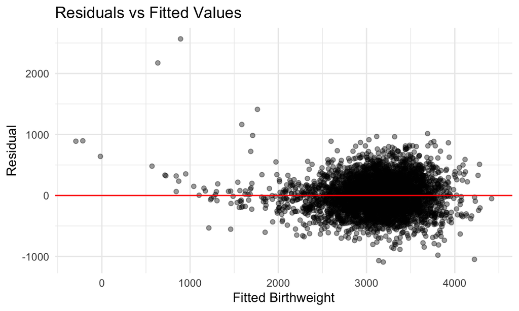

```r
birthweight |>
  add_predictions(linear_prop) |>
  add_residuals(linear_prop) |>
  ggplot(aes(x = pred, y = resid)) +
  geom_point(alpha = 0.4) +
  geom_hline(yintercept = 0, color = "red") +
  labs(
    title = "Residuals vs Fitted Values",
    x = "Fitted Birthweight",
    y = "Residual"
  ) +
  theme_minimal()
```

The Residuals vs Fitted Values plot is used to assess whether linearity, constant variance of residuals, and independence of errors—are satisfied.

**Compare your model to two others:**

- A model using length at birth and gestational age as predictors (main effects only)

```r
linear_main = lm(bwt ~ blength + gaweeks, data = birthweight)
```

- A model using head circumference, length, sex, and all interactions (including the three-way interaction) between these

```r
linear_interaction = lm(bwt ~ bhead * blength * babysex, data = birthweight)
```

**Make this comparison in terms of the cross-validated prediction error; use crossv_mc and functions in purrr as appropriate.**

```r
cv_df =
  crossv_mc(birthweight, n = 100, test = 0.2) |>
  mutate(
    train = map(train, as_tibble),
    test = map(test, as_tibble)
  )
```

For each split, models were trained on the training subset and evaluated using Root Mean Squared Error (RMSE) on the test data.

```r
cv_df =
  cv_df |>
  mutate(
    linear_prop =
      map(train,
          \(df) lm(bwt ~ bhead + blength + gaweeks + ppbmi + smoken + wtgain + babysex,
                   data = df)),
    linear_main =
      map(train, \(df) lm(bwt ~ blength + gaweeks, data = df)),
    linear_interaction =
      map(train, \(df) lm(bwt ~ bhead * blength * babysex, data = df)),
  ) |>
  mutate(
    rmse_prop = map2_dbl(linear_prop, test, rmse),
    rmse_main = map2_dbl(linear_main, test, rmse),
    rmse_interaction = map2_dbl(linear_interaction, test, rmse)
  )
```

```r
cv_df |>
  summarize(
    RMSE_prop  = mean(rmse_prop),
    RMSE_Main  = mean(rmse_main),
    RMSE_Inter = mean(rmse_interaction)
  ) |>
  knitr::kable()
```

| RMSE_prop | RMSE_Main | RMSE_Inter |
| --- | --- | --- |
| 283.0541 | 332.2341 | 288.995 |

The proposed model, which incorporates fetal measurements (head circumference, length, gestational age), maternal variables (BMI, weight gain, smoking), and infant sex, achieved the lowest RMSE (283.05). The interaction model, which includes head circumference, length, sex, and all two- and three-way interactions, had a higher RMSE (288.99). The simple model using only birth length and gestational age produced the highest RMSE (332.23), indicating the weakest predictive ability.

My proposed model provides the highest predictive accuracy for birthweight. :)